# Soal 3

## Pertanyaan

#### 3a. Lakukan analisis dengan teknik yang sudah dipelajari

Analisis data dilakukan dengan menerapkan binary classification untuk memprediksi Credit Risk (Low atau High) menggunakan model logistic regression

#### 3b. Jelaskan mengapa teknik tersebut yang anda pakai

Model logistic regression digunakan karena model ini adalah salah satu model yang secara alami ditujukan untuk penyelesaian kasus binary classification, dimana prediksi hanya berisikan dua class.

- Model ini mudah untuk diimplementasikan, diinterpretasi, serta sangat efisien untuk melatih model.
- Model ini tidak memiliki asumsi terkait distribusi class di feature space.
- Model ini memberikan arah asosiasi dengan variabel respon (positif atau negatif).
- Model ini cepat untuk mengklasifikasikan record baru.
- Model ini baik untuk memprediksi ketika data dapat dipisahkan secara linier.
- Koefisien model dapat digunakan sebagai indikator feature importance.
- Model ini cenderung kecil kemungkinan untuk overfitting, namun pada dimensi data yang tinggi, mungkin perlu digunakan regularisasi untuk menghindari overfitting.

Sumber: https://www.geeksforgeeks.org/advantages-and-disadvantages-of-logistic-regression/

#### 3c. Apakah Anda perlu menggunakan Pre Processing? Jika YA jelaskan PreProcessing apa yang Anda perlukan

Preprocessing yang digunakan dalam membuat model adalah

1. Cek null values
2. Drop kolom data yang kategorikal (nominal dan ordinal)
3. Feature scaling dengan min-max scalling skala 0-1
4. Menyeleksi feature dengan melihat korelasi antara variabel prediktor
5. Membagi data ke train dan test dataset
6. Membuat train dataset memiliki kelas yang seimbang dengan up sample

#### 3d. Hasil apa yang bisa Anda dapatkan dari data yang sudah diolah dan berikan penjelasan apa manfaatnya terkait pengambilan keputusan

Dengan hanya mengandalkan metric accuracy, saya mendapat nilai accuracy sebesar 0,5952381. Dengan membuat model prediksi credit risk, maka penyedia jasa kredit memiliki sistem pendukung keputusan untuk menerima atau menolak pengajuan kredit. Namun dengan hasil accuracy model yang relatif rendah ini maka masih dibutuhkan proses lebih lanjut untuk membuat model yang layak untuk membantu pengambilan keputusan. Cara yang dapat digunakan meliputi:

- Eliminasi outlier dengan capping dan flooring
- Menggunakan cross validation
- Menggunakan teknik regularisasi (L1 dan L2)
- Menggunakan model binary classification lainnya

```r
#install.packages("readxl")
library(readxl)
df_raw = read_excel("D:/Kuliah/Semester 1/Data Mining dan Business Intelligence/UTS/Credit Risk Data.xlsx", sheet="Base Data", skip=2)
df_test_pred_model_raw = read_excel("D:/Kuliah/Semester 1/Data Mining dan Business Intelligence/UTS/Credit Risk Data.xlsx", sheet="Additional Data")
head(df_raw)
```

```
## # A tibble: 6 × 12
##   Loan Purp…¹ Check…² Savings Month…³ Month…⁴ Gender Marit…⁵   Age Housing Years
##   <chr>         <dbl>   <dbl>   <dbl>   <dbl> <chr>  <chr>   <dbl> <chr>   <dbl>
## 1 Small Appl…       0     739      13      12 M      Single     23 Own         3
## 2 Furniture         0    1230      25       0 M      Divorc…    32 Own         1
## 3 New Car           0     389      19     119 M      Single     38 Own         4
## 4 Furniture       638     347      13      14 M      Single     36 Own         2
## 5 Education       963    4754      40      45 M      Single     31 Rent        3
## 6 Furniture      2827       0      11      13 M      Married    25 Own         1
## # … with 2 more variables: Job <chr>, `Credit Risk` <chr>, and abbreviated
## #   variable names ¹`Loan Purpose`, ²Checking, ³`Months Customer`,
## #   ⁴`Months Employed`, ⁵`Marital Status`
```

```r
head(df_test_pred_model_raw)
```

```
## # A tibble: 6 × 12
##   Loan Purp…¹ Check…² Savings Month…³ Month…⁴ Gender Marit…⁵   Age Housing Years
##   <chr>         <dbl>   <dbl>   <dbl>   <dbl> <chr>  <chr>   <dbl> <chr>   <dbl>
## 1 Education       600    3500      30      45 M      Single     27 Rent        3
## 2 Business        500     800      15      20 f      Married    26 Rent        1
## 3 New Car         250     250      15      48 M      Single     25 Own         3
## 4 Furniture       101    3871      10      16 F      Single     26 Own         4
## 5 Small Appl…     300     400      10       5 m      Divorc…    28 Own         2
## 6 Business        790    3000       8      24 M      Single     38 Rent        7
## # … with 2 more variables: Job <chr>, `Credit Risk` <lgl>, and abbreviated
## #   variable names ¹`Loan Purpose`, ²Checking, ³`Months Customer`,
## #   ⁴`Months Employed`, ⁵`Marital Status`
```

```r
str(df_raw)
```

```
## tibble [425 × 12] (S3: tbl_df/tbl/data.frame)
##  $ Loan Purpose   : chr [1:425] "Small Appliance" "Furniture" "New Car" "Furniture" ...
##  $ Checking       : num [1:425] 0 0 0 638 963 ...
##  $ Savings        : num [1:425] 739 1230 389 347 4754 ...
##  $ Months Customer: num [1:425] 13 25 19 13 40 11 13 14 37 25 ...
##  $ Months Employed: num [1:425] 12 0 119 14 45 13 16 2 9 4 ...
##  $ Gender         : chr [1:425] "M" "M" "M" "M" ...
##  $ Marital Status : chr [1:425] "Single" "Divorced" "Single" "Single" ...
##  $ Age            : num [1:425] 23 32 38 36 31 25 26 27 25 43 ...
##  $ Housing        : chr [1:425] "Own" "Own" "Own" "Own" ...
##  $ Years          : num [1:425] 3 1 4 2 3 1 3 1 2 1 ...
##  $ Job            : chr [1:425] "Unskilled" "Skilled" "Management" "Unskilled" ...
##  $ Credit Risk    : chr [1:425] "Low" "High" "High" "High" ...
```

From the dataset above, tht columns with character type will be dropped since it represent nominal datatype, but keepiing the credit risk for response variable

## Summary Statistics

```r
summary(df_raw)
```

```
##  Loan Purpose          Checking        Savings      Months Customer
##  Length:425         Min.   :    0   Min.   :    0   Min.   : 5.0
##  Class :character   1st Qu.:    0   1st Qu.:  228   1st Qu.:13.0
##  Mode  :character   Median :    0   Median :  596   Median :19.0
##                     Mean   : 1048   Mean   : 1813   Mean   :22.9
##                     3rd Qu.:  560   3rd Qu.:  921   3rd Qu.:28.0
##                     Max.   :19812   Max.   :19811   Max.   :73.0
##  Months Employed    Gender          Marital Status          Age
##  Min.   :  0.0   Length:425         Length:425         Min.   :18.0
##  1st Qu.:  6.0   Class :character   Class :character   1st Qu.:26.0
##  Median : 20.0   Mode  :character   Mode  :character   Median :32.0
##  Mean   : 31.9                                         Mean   :34.4
##  3rd Qu.: 47.0                                         3rd Qu.:41.0
##  Max.   :119.0                                         Max.   :73.0
##    Housing              Years          Job            Credit Risk
##  Length:425         Min.   :1.00   Length:425         Length:425
##  Class :character   1st Qu.:2.00   Class :character   Class :character
##  Mode  :character   Median :3.00   Mode  :character   Mode  :character
##                     Mean   :2.84
##                     3rd Qu.:4.00
##                     Max.   :4.00
```

### Check for Null Value

```r
lapply(df_raw,function(x) { length(which(is.na(x)))})
```

```
## $`Loan Purpose`
## [1] 0
##
## $Checking
## [1] 0
##
## $Savings
## [1] 0
##
## $`Months Customer`
## [1] 0
##
## $`Months Employed`
## [1] 0
##
## $Gender
## [1] 0
##
## $`Marital Status`
## [1] 0
##
## $Age
## [1] 0
##
## $Housing
## [1] 0
##
## $Years
## [1] 0
##
## $Job
## [1] 0
##
## $`Credit Risk`
## [1] 0
```

```r
df_clean = df_raw
```

### Drop categorical (nominal and ordinal) columns

```r
#library(psych)

#ints<-sapply(df_clean, is.integer)

#df_clean_int = as.data.frame(apply(df_clean[,ints],2,as.numeric))
df_clean_num = df_clean[, sapply(df_clean, is.numeric)]
#str(df_clean_num)
#df_clean_num = df_clean_num[c(-3, -4, -7, -8, -11, -14, -19)]
str(df_clean_num)
```

```
## tibble [425 × 6] (S3: tbl_df/tbl/data.frame)
##  $ Checking       : num [1:425] 0 0 0 638 963 ...
##  $ Savings        : num [1:425] 739 1230 389 347 4754 ...
##  $ Months Customer: num [1:425] 13 25 19 13 40 11 13 14 37 25 ...
##  $ Months Employed: num [1:425] 12 0 119 14 45 13 16 2 9 4 ...
##  $ Age            : num [1:425] 23 32 38 36 31 25 26 27 25 43 ...
##  $ Years          : num [1:425] 3 1 4 2 3 1 3 1 2 1 ...
```

### Feature Scalling

```r
#install.packages("conflicted")
library(conflicted)
conflict_prefer("apply", "base")
```

```
## [conflicted] Will prefer base::apply over any other package
```

```r
# Create Response Variable as DataFrame
df_target=as.data.frame(df_clean[c(12)])

# Norm Z function declaration
normalisasi=function(x){
  xm=colMeans(x)
  jb=dim(x)[1]
  xc=x-rep(xm,each=jb)
  sdx=apply(x,2,sd)
  xstd=xc/rep(sdx,each=jb)
  output=data.frame(xstd)
  #output=data.frame(xstd,x)
  return(output)
}


# Min-Max Norm function declaration
min_max_norm <- function(x) {
    (x - min(x)) / (max(x) - min(x))
  }

# Normalization
#df_norm = normalisasi(df_clean_num)
df_norm = as.data.frame(lapply(df_clean_num, min_max_norm))

# Outer Join Dataset
df_norm = data.frame(df_target,df_norm)

# Label encoding for response variable
df_norm$Credit.Risk = ifelse(df_norm$Credit.Risk=="High",1,0)
df_norm$Credit.Risk = factor(df_norm$Credit.Risk, levels = c(0,1))
#df_norm
#head(df_norm)
#str(df_norm)
#unique(df_norm$Attrition)
```

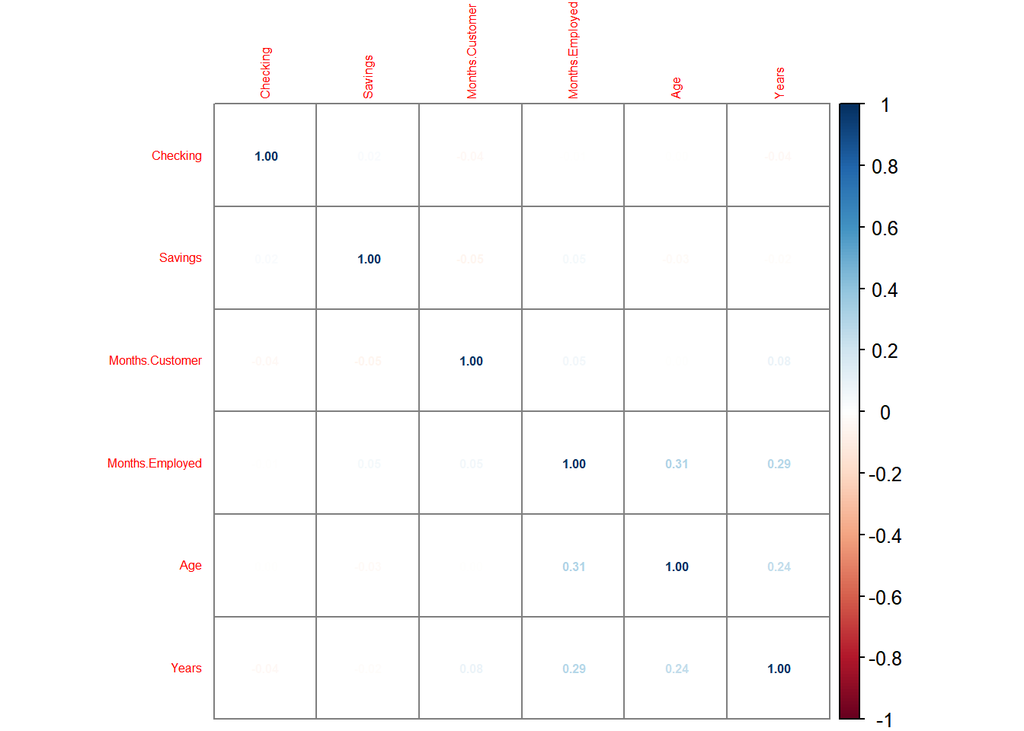

```r
#install.packages("corrplot")
library(psych)
library(corrplot)
#corPlot(cor(df_norm[(-1)]), cex=0.3, tl.cex=1, xlas=3)
corrplot(cor(df_norm[(-1)], df_norm[(-1)]),
         method = c("number"),
         #bg = "grey10",
         addgrid.col = "gray50",
         tl.cex=0.5,
         number.cex=0.5)
```

from this correlation graph, we knew that there are no stong correlation (>0.5), therefore there is no need for feature selection

### Create Class Balanced Train and test Dataset

```r
#install.packages("caret")
library(caret)
'%ni%' = Negate('%in%')
options(scipen=999)

set.seed(100)
str(df_norm)
```

```
## 'data.frame':    425 obs. of  7 variables:
##  $ Credit.Risk    : Factor w/ 2 levels "0","1": 1 2 2 2 1 1 1 1 2 2 ...
##  $ Checking       : num  0 0 0 0.0322 0.0486 ...
##  $ Savings        : num  0.0373 0.0621 0.0196 0.0175 0.24 ...
##  $ Months.Customer: num  0.118 0.294 0.206 0.118 0.515 ...
##  $ Months.Employed: num  0.101 0 1 0.118 0.378 ...
##  $ Age            : num  0.0909 0.2545 0.3636 0.3273 0.2364 ...
##  $ Years          : num  0.667 0 1 0.333 0.667 ...
```

```r
df_train_test= df_norm
```

```r
trainDataIndex= createDataPartition(df_train_test$Credit.Risk, p=0.8, list = F)

trainData = df_train_test[trainDataIndex,]
testData = df_train_test[-trainDataIndex,]

# Down sample
set.seed(100)
down_train=downSample(x=trainData[, colnames(trainData)%ni%"Credit.Risk"], y=trainData$Credit.Risk)
#table(down_train$Class)

# Up Sample
set.seed(100)
up_train = upSample(x = trainData[, colnames(trainData)%ni%"Credit.Risk"], y = trainData$Credit.Risk)
table(up_train$Class)
```

```
##
##   0   1
## 172 172
```

### Create Logistic Regression Model

```r
logitmod = glm(Class~., family = "binomial", data=up_train)
summary(logitmod)
```

```
##
## Call:
## glm(formula = Class ~ ., family = "binomial", data = up_train)
##
## Deviance Residuals:
##      Min        1Q    Median        3Q       Max
## -1.87096  -1.09950   0.00417   1.12067   1.85504
##
## Coefficients:
##                 Estimate Std. Error z value  Pr(>|z|)
## (Intercept)      -0.5232     0.3010  -1.738    0.0822 .
## Checking         -0.5615     0.6547  -0.858    0.3911
## Savings          -0.9234     0.6141  -1.504    0.1327
## Months.Customer   2.6045     0.6656   3.913 0.0000912 ***
## Months.Employed  -0.8607     0.4522  -1.903    0.0570 .
## Age              -0.4323     0.6104  -0.708    0.4788
## Years             0.5338     0.3301   1.617    0.1059
## ---
## Signif. codes:  0 '***' 0.001 '**' 0.01 '*' 0.05 '.' 0.1 ' ' 1
##
## (Dispersion parameter for binomial family taken to be 1)
##
##     Null deviance: 476.89  on 343  degrees of freedom
## Residual deviance: 449.63  on 337  degrees of freedom
## AIC: 463.63
##
## Number of Fisher Scoring iterations: 4
```

### Model Validation using Accuracy Metrics

```r
pred <- predict(logitmod, testData, type = "response")

y_pred_num = ifelse(pred>0.5,1,0)
y_pred = factor(y_pred_num, levels=c(0,1))
y_act = testData$Credit.Risk

mean(y_pred==y_act)
```

```
## [1] 0.5714286
```

## Feature Selection Based On P-value

### Create Class Balanced Train and test Dataset

```r
#install.packages("caret")
library(caret)
'%ni%' = Negate('%in%')
options(scipen=999)

set.seed(100)
str(df_norm)
```

```
## 'data.frame':    425 obs. of  7 variables:
##  $ Credit.Risk    : Factor w/ 2 levels "0","1": 1 2 2 2 1 1 1 1 2 2 ...
##  $ Checking       : num  0 0 0 0.0322 0.0486 ...
##  $ Savings        : num  0.0373 0.0621 0.0196 0.0175 0.24 ...
##  $ Months.Customer: num  0.118 0.294 0.206 0.118 0.515 ...
##  $ Months.Employed: num  0.101 0 1 0.118 0.378 ...
##  $ Age            : num  0.0909 0.2545 0.3636 0.3273 0.2364 ...
##  $ Years          : num  0.667 0 1 0.333 0.667 ...
```

```r
df_train_test= df_norm[c(-2, -3, -6, -7)]
```

```r
trainDataIndex= createDataPartition(df_train_test$Credit.Risk, p=0.8, list = F)

trainData = df_train_test[trainDataIndex,]
testData = df_train_test[-trainDataIndex,]

# Down sample
set.seed(100)
down_train=downSample(x=trainData[, colnames(trainData)%ni%"Credit.Risk"], y=trainData$Credit.Risk)
#table(down_train$Class)

# Up Sample
set.seed(100)
up_train = upSample(x = trainData[, colnames(trainData)%ni%"Credit.Risk"], y = trainData$Credit.Risk)
table(up_train$Class)
```

```
##
##   0   1
## 172 172
```

### Create Logistic Regression Model

```r
logitmod = glm(Class~., family = "binomial", data=up_train)
summary(logitmod)
```

```
##
## Call:
## glm(formula = Class ~ ., family = "binomial", data = up_train)
##
## Deviance Residuals:
##      Min        1Q    Median        3Q       Max
## -1.89878  -1.08451  -0.06335   1.15513   1.62399
##
## Coefficients:
##                 Estimate Std. Error z value  Pr(>|z|)
## (Intercept)      -0.5021     0.2243  -2.239    0.0252 *
## Months.Customer   2.7141     0.6590   4.118 0.0000382 ***
## Months.Employed  -0.7737     0.4158  -1.861    0.0628 .
## ---
## Signif. codes:  0 '***' 0.001 '**' 0.01 '*' 0.05 '.' 0.1 ' ' 1
##
## (Dispersion parameter for binomial family taken to be 1)
##
##     Null deviance: 476.89  on 343  degrees of freedom
## Residual deviance: 455.84  on 341  degrees of freedom
## AIC: 461.84
##
## Number of Fisher Scoring iterations: 4
```

### Model Validation using Accuracy Metrics

```r
pred <- predict(logitmod, testData, type = "response")

y_pred_num = ifelse(pred>0.5,1,0)
y_pred = factor(y_pred_num, levels=c(0,1))
y_act = testData$Credit.Risk

mean(y_pred==y_act)
```

```
## [1] 0.5952381
```

```r
#library(dplyr)
#head(df_test_pred_model_raw)
#df_test_pred_model = df_test_pred_model_raw %>%
```